# Analys av föräldraförmåga

Göteborgs Stad

Författare

Anknuten

Marit Preuter, Ekaterina Ivanova, Anna Svensén Burgman och Louise Arvidsson

[RISE Research Institutes of Sweden och Göteborgs Stad](https://www.ri.se/sv/shic)

Utgiven

17 mars 2026

# 1 Inledning

I den nya socialtjänstlagen som trädde i kraft i juli 2025 ställs nya krav på kommunen att planera sina insatser. Tidigare har kraven om planering endast omfattat särskilda boenden för äldre och bostäder med särskild service till personer med funktionsnedsättning. I och med den nya lagstiftningen har planeringskravet utvidgats till att omfatta alla insatser, både till enskilda och till grupper, så att kommunens insatser är dimensionerade att möta befolkningens behov. Planeringen ska även fokusera på tidiga och förebyggande insatser med syfte att minska framtida behov av mer omfattade insatser. Detta ställer högre krav på att kommunerna har kunskap om olika målgruppers behov, inte enbart bland de brukare som kommunen redan möter i sin verksamhet, utan hos befolkningen i stort.

**Föräldraskapsstöd i Göteborg**

Föräldraskapsstöd definieras som ”…insatser, aktiviteter och verksamheter riktade till föräldrar som stärker föräldraförmågan och relationen mellan förälder och barn. Det kan handla om att ge föräldrar kunskap om barnets rättigheter, hälsa och utveckling, att stärka föräldrars relation till varandra eller deras sociala nätverk” (Socialstyrelsen, 2018) I den nationella strategin för stärkt föräldraskapsstöd betonas tidiga, hälsofrämjande insatser som en central del i arbetet för en jämlik uppväxt och ett förstärkt skyddsnät kring barnet (Socialstyrelsen, 2018). Föräldrars behov av stöd varierar och förändras under barnets uppväxt beroende på barnets utvecklingsfas, händelser i familjen och omgivande miljö. Eftersom dagens familjekonstellationer ser olika ut är det avgörande att samhället erbjuder anpassade former av stöd oberoende av bakgrund och livssituation.

Göteborgs Stad erbjuder föräldraskapsstöd både som universella och riktade insatser. Stödet ges i olika former, från individuella råd och stödsamtal till föräldrastödsprogram i grupp. Eftersom föräldrar inte är en homogen grupp varierar behoven av information, handledning och praktiskt stöd. Trots att intresset för stöd är stort visar forskning från Göteborgs universitet att kännedomen om det befintliga utbudet generellt är låg, i synnerhet bland tonårsföräldrar (Thorslund, 2019).

I linje med ett växande fokus på tidiga och förebyggande insatser har Göteborgs Stad, tillsammans med RISE, undersökt hur föräldraskapsstöd kan bidra till att minska riskfaktorer kopplade till ungas kriminalitet (Odhnoff, Johansson, Preuter & Larsson, 2024). Inom ramen för ett uppdrag i stadens budget 2022 utvecklades en modell för att bedöma de samhällsekonomiska effekterna av föräldrastödsprogram, med Alla barn i centrum (ABC) som exempel. Analysen visade att stärkt föräldraskap kan påverka barns beteende i en riktning som både gynnar deras utveckling och minskar behovet av framtida stödinsatser. Resultaten indikerar att föräldrastödsprogram inte bara stärker relationen mellan barn och föräldrar, utan även kan utgöra en del av stadens långsiktiga brottsförebyggande arbete. Mot denna bakgrund uppstod frågan vilka målgrupper som faktiskt tar del av föräldraskapsstödet idag – och vilka som har störst behov av det.

Under år 2024 genomförde Göteborgs Stad i samarbete med RISE målgruppsanalyser av ett flertal föräldrastödsprogram som utförs i stadens regi (Odhnoff, 2025). Inom ramen för analyserna sammanställdes statistik om deltagandet i föräldrastödprogrammen och om målgruppen i stort, både vad gäller gruppernas storlek och deras sammansättning. På så sätt gav analyserna en bild av omfattningen av deltagandet utifrån den potentiella målgruppen i befolkningen samt om det finns grupper av föräldrar som inte tar del av stöden i samma utsträckning som andra. Under arbetet med målgruppsanalyserna identifierades en kunskapslucka kring huruvida det finns skillnader mellan olika grupper av föräldrar i Göteborg när det gäller behov av föräldraskapsstöd. Det är oklart om grupperna upplever olika typer av utmaningar och om det finns grupper som kommunen särskilt bör rikta sina insatser till.

För att ta reda på det har Göteborgs Stad tillsammans med RISE tagit fram en enkät med syfte att mäta föräldraförmåga. Under hösten 2025 gick enkäten ut till 10 000 slumpmässigt utvalda föräldrar i Göteborg med barn i åldrarna 0–18 år. Enkäten utgör ett första steg att närma sig nya sätt att mäta föräldraförmåga och att få en bättre bild över behoven av föräldraskapsstöd bland olika grupper.

# 2 Bakgrund

## 2.1 Vad är föräldraförmåga?

Begreppet föräldraförmåga är mångdimensionellt och saknar en enskild universell definition; i stället används olika perspektiv beroende på om fokus ligger på funktion, relation eller kontext. Inom socialtjänstens praktiska arbete, och i enlighet med grundboken för Barns behov i centrum, används ofta en funktionell definition. Denna beskriver föräldraförmåga som förälderns faktiska kapacitet att tillgodose barnets behov av grundläggande omsorg, trygghet, stimulans och stabilitet (Socialstyrelsen, 2024). Här betraktas förmågan som en konkret uppsättning färdigheter som krävs för att säkerställa barnets fysiska och psykiska hälsa genom olika utvecklingsstadier. Samtidigt betonar forskningen vikten av en relationell definition, där föräldraförmågan snarare sammankopplas med förälderns förmåga till anknytning. Det handlar då inte enbart om praktiska handlingar, utan om förälderns psykologiska beredskap att tolka och svara adekvat på barnets inre känsloliv och behov (Belsky, 1984).

En nyligen genomförd forskningsöversikt av Ndengeyingoma m.fl. (2024) preciserar detta genom att identifiera specifika förmågor hos föräldrar som viktiga för barnets sociala och emotionella utveckling. De olika förmågorna sorteras under fyra kategorier: känslomedvetenhet, att vara tillgänglig för stöd, föräldrastil och stresshantering. Dessa uttrycks genom tex. bra förmåga att hjälpa barnet att hantera sina känslor, stödja barnets autonomi, skapa en varm hemmiljö samt att vara närvarande i interaktioner med barnet och är alla kopplade till barnets positiva utveckling. Ur detta perspektiv är föräldraförmågan inte en statisk egenskap hos individen, utan en dynamisk process som ständigt påverkas av barnets mognad och de förväntningar som omgivningen ställer. För att förstå detta samspel är Bronfenbrenners teori om föräldraförmåga en central utgångspunkt (Bronfenbrenner, 1979). Bronfenbrenner beskriver hur föräldraförmågan formas genom allt som omger föräldern - från familjen och skolan till arbetslivet och samhället i stort. Därför kan föräldraskapet inte betraktas isolerat från förälderns övriga livssituation. Detta helhetsperspektiv bekräftas i den nationella strategin för ett stärkt föräldraskapsstöd, som tydliggör att definitionen av föräldraförmåga även måste inrymma samhällets ansvar att erbjuda de stödresurser som krävs för att stärka individens förutsättningar i sitt föräldraskap (Socialstyrelsen, 2018).

**Risk- och skyddsfaktorer under uppväxten**

Många stora samhällsutmaningar, som missbruk, kriminalitet och psykisk ohälsa, har ofta gemensamma rötter i familjemiljön. Enligt en rapport från RISE (2021) utgör återkommande familjekonflikter, en hård eller inkonsekvent uppfostran samt bristande uppsyn över barnet betydande riskfaktorer. Dessa omständigheter ökar sannolikheten för att barnet senare utvecklar sociala problem eller hamnar i utanförskap.

Som motvikt fungerar starka känslomässiga band, en varm men tydlig gränssättning och föräldrars engagemang i barnets vardag som centrala skyddsfaktorer. Föräldraskapsstöd syftar till att stärka dessa skyddande funktioner och bryta negativa utvecklingsspiraler. Även om insatserna fokuserar på samspelet inom familjen, poängterar rapporten att föräldraförmågan alltid påverkas av yttre livsvillkor. Ekonomisk stress eller brist på socialt nätverk kan dränera de resurser som krävs för ett fungerande föräldraskap. Att erbjuda stöd tidigt är därför ett sätt för samhället att kompensera för yttre påfrestningar och därmed skydda barnets långsiktiga utveckling (RISE, 2021).

## 2.2 Att mäta föräldraförmåga

Det finns flera viktiga anledningar till att mäta föräldraförmåga i samhället. Det är nödvändigt att kunna fånga upp utbredd bristande föräldraförmåga i och med att den ökar risken för en negativ utveckling för barnet. Att få kännedom om bristerna gör det möjligt att införa relevanta insatser i ett tidigt skede, vilket är särskilt aktuellt i och med den nya socialtjänstlagen som ger socialtjänsten det utökade uppdraget att arbeta med förebyggande insatser i samhället. Den reviderade lagstiftningen ställer högre krav på att insatser planeras och utformas utifrån individers livssituation, samt att kommuner arbetar systematiskt med uppföljning, utvärdering och verksamhetsutveckling. Tillförlitlig mätning av föräldraförmåga är nödvändigt för att möta dessa krav och vidareutveckla stödet till föräldrar. Mätning av föräldraförmåga kan ske på samhällsnivå för att utvärdera universella insatser som berör alla – exempelvis justeringar i föräldraförsäkringen – samt på individnivå när man vill följa upp interventioner av behandlande karaktär. Mätningar är även nödvändiga för att kunna följa utveckling över tid och fånga upp en eventuell försämring i ett tidigt skede.

# 3 Metod

## 3.1 Utvecklingsprocess för enkäten

RISE har tidigare, på uppdrag av Myndigheten för familjerätt och föräldraskapsstöd (MFoF), genomfört en kartläggning av hur en ändamålsenlig struktur för uppföljning av föräldraskapsstöd kan utformas samt vilka indikatorer och mätverktyg som en sådan struktur skulle kunna omfatta (RISE, 2022). Arbetet visade att det i dagsläget råder en stor diskrepans mellan det föräldraskapsstöd som erbjuds och hur det följs upp. Många av de enkäter som används i praktiken i Sverige saknar tillräcklig kvalitet gällande validitet och reliabilitet, vilket gör det svårt att uttala sig om faktiska effekter. Slutsatsen understryker behovet av att standardisera uppföljningen med fokus på föräldraförmåga som det främsta effektmåttet.

Utifrån detta behov togs ett första urval av enkätfrågor fram av forskare vid Karolinska Institutet, Uppsala universitet och RISE. Frågorna utarbetades för att täcka centrala aspekter av föräldraförmåga samt upplevt behov av föräldraskapsstöd. Därefter utvecklades, förtydligades och anpassades frågorna vidare genom dialog med ämnesexperter inom föräldraskapsstöd i Göteborgs Stad för att säkerställa både praktisk relevans och begreppsmässig tydlighet. En första testomgång av enkäten genomfördes därefter. Den besvarades av medarbetare vid RISE och Göteborgs Stad som själva var föräldrar (n = 144). Datamaterialet analyserades med Rasch-analys via verktyget easyRasch (https://pgmj.github.io/easyRasch/). Analysen indikerade flera förbättringsmöjligheter, bland annat avseende svarsalternativens utformning och skalstegens ordning. Baserat på dessa resultat vidareutvecklades enkäten innan den användes i den fullskaliga utvärderingen.

## 3.2 Den fullskaliga utvärderingen

Datainsamlingen genomfördes i Göteborgs Stad under oktober 2025. Urvalet av deltagare baserades på uppgifter från folkbokföringen, där personer identifierades utifrån att de var föräldrar bosatta i Göteborgs Stad med barn i åldrarna 0–18 år. Ett slumpmässigt urval av 10 000 föräldrar gjordes och dessa personer kontaktades via den digitala tjänsten Mina meddelanden med en förfrågan om att besvara enkäten. Från folkbokföringen inhämtades även vissa bakgrundsvariabler, såsom vilket område i staden föräldern är bosatt i samt hur många barn denne är vårdnadshavare för. Enkäten fanns endast tillgänglig på svenska.

För att säkerställa deltagarnas anonymitet har svaren i undersökningen hanterats helt separat från personuppgifterna. Ingen av de som genomförde eller analyserade undersökningen har haft tillgång till information som möjliggör identifiering av enskilda svarande. Efter avslutad datainsamling har samtliga identifierande uppgifter raderats, vilket gör det omöjligt att i efterhand koppla enskilda svar till specifika personer.

# 4 Resultat: enkätutvärdering genom Rasch-analys

Enkätens mätegenskaper analyserades med hjälp av Rasch-modellering. I analysen omvandlades svarsalternativen till numeriska värden enligt följande: ”Aldrig” = 0, ”Sällan” = 1, ”Ibland” = 2, ”Ofta” = 3 och ”Mycket ofta” = 4. Dessa poäng används i Rasch-modellen för att analysera om frågorna fungerar väl för att mäta föräldraförmåga, det vill säga om de tillsammans bildar en tillförlitlig och sammanhängande skala. Poängsättningen används också för att beräkna varje deltagares resultat.

Resultaten av rasch-analysen visade att frågorna inte kunde slås samman till ett enda sammanhållet index. I stället identifierades fyra separata delindex, baserat både på psykometriska kriterier och på behovet av att enkäten ska kunna användas praktiskt av verksamheter inom föräldraskapsstöd. Varje delindex mäter en särskild förmåga kopplat till föräldraskap.

## 4.1 Beskrivning av delindex

Nedan listas de frågor som ingår i de fyra delindexen.

**Delindex:**

- **1** – Förmåga att hantera situationer där det uppstår irritation
- **2** – Förmåga att skapa positiv samvaro
- **3** – Förmåga att hantera oro eller rädsla hos barnet
- **4** – Förmåga att hantera situationer där det uppstår bråk

> **Inledande fråga** Dessa frågor fungerar som introduktion till de frågor som ingår i ett delindex. De inledande frågorna används enbart som kontext och inkluderas därför *inte* i själva delindexberäkningen.

> **Indexfråga** Dessa frågor används för att beräkna de respektive fyra delindexen.

**Svarsalternativ** – Frågorna kan besvaras med svarsalternativen: Aldrig, Sällan, Ibland, Ofta, Mycket ofta.

## 4.2 Delindex **1** – Förmåga att hantera situationer där det uppstår irritation

**Innehåll**

1. **Inledande fråga** Hur ofta har ditt barn gjort saker som irriterat eller stört dig under en typisk vecka tillsammans den senaste tiden?
2. **Indexfråga** Hur hanterade du det? [Uttryckte dig lugnt, fast du kände dig irriterad eller arg.]
3. **Indexfråga** Hur hanterade du det? [Avstod från att säga till om saker som störde dig, men som egentligen inte var så viktiga.]

## 4.3 Delindex **2** – Förmåga att skapa positiv samvaro

**Innehåll**

1. **Indexfråga** Under en typisk vecka tillsammans den senaste tiden, hur ofta har du…  
   [Gett ditt barn full uppmärksamhet en stund, utan att samtidigt vara upptagen med annat?]
2. **Indexfråga** Under en typisk vecka tillsammans den senaste tiden, hur ofta har du…  
   [Visat nyfikenhet för något som barnet höll på med (t.ex. tittade på en stund när det ritade eller spelade datorspel).]
3. **Indexfråga** Under en typisk vecka tillsammans den senaste tiden, hur ofta har du…  
   [Pratat om något som barnet ville prata om (t.ex. om något tv-program eller något som hänt under dagen eller i livet).]
4. **Indexfråga** Under en typisk vecka tillsammans den senaste tiden, hur ofta har du…  
   [Visat omtanke eller uppskattning, även när ditt barn inte hade gjort något särskilt (t.ex. en kram utan direkt anledning).]
5. **inledande fråga** Hur ofta har ditt barn gjort något du uppskattar under en typisk vecka tillsammans den senaste tiden?
6. **Indexfråga** Hur ofta visade du ditt barn att du uppskattade det hen gjorde?

Eftersom väldigt få respondenter svarade “Aldrig” på indexfrågorna 3, 4 och 6, slogs detta svarsalternativ för dessa frågor ihop med svarsalternativet “Sällan” som tillsammans kodas som 0 poäng i analysen, “Ibland” kodas som 1 poäng, “Ofta” som 2 poäng och “Mycket ofta” som 3 poäng.

Sammanläggningen gjordes för att säkerställa att svarskategorierna fungerade tillfredsställande i Rasch-analysen, det vill säga att varje kategori hade tillräckligt många observationer och att trösklarna mellan kategorierna var ordnade.

## 4.4 Delindex **3** – Förmåga att hantera oro eller rädsla hos barnet

**Innehåll**

1. **Inledande fråga** Hur ofta har ditt barn varit oroligt eller ängsligt under en typisk vecka tillsammans den senaste tiden?
2. **Indexfråga** Hur hanterade du det?  
   [Uppmuntrade ditt barn att prova, göra fel och försöka igen utan att du genast hjälpte till eller tog över.]
3. **Indexfråga** Hur hanterade du det? [Pratade med barnet om hens känslor.]
4. **Indexfråga** Hur hanterade du det? [Hjälpte lite på traven för att barnet skulle våga.]

Eftersom väldigt få respondenter svarade “Aldrig” på indexfrågorna 2 och 4, slogs detta svarsalternativ för dessa frågor ihop med svarsalternativet “Sällan” som tillsammans kodas som 0 poäng i analysen, “Ibland” kodas som 1 poäng, “Ofta” som 2 poäng och “Mycket ofta” som 3 poäng.

Sammanläggningen gjordes för att säkerställa att svarskategorierna fungerade tillfredsställande i Rasch-analysen, det vill säga att varje kategori hade tillräckligt många observationer och att trösklarna mellan kategorierna var ordnade.

## 4.5 Delindex **4** – Förmåga att hantera situationer där det uppstår bråk

**Innehåll**

1. **Inledande fråga** Hur ofta har ditt barn bråkat under en typisk vecka tillsammans den senaste tiden?
2. **Indexfråga** Hur hanterade du det?  
   [Försökte avleda konflikt, till exempel genom att börja skoja, busa eller prata om något annat.]
3. **Indexfråga** Hur hanterade du det? [Visade förståelse för barnets känslor.]
4. **Indexfråga** Hur hanterade du det?  
   [Stod fast vid saker som ni hade bestämt, trots att barnet fortsatte att bråka.]

Eftersom väldigt få respondenter svarade “Aldrig” på indexfrågorna 3 och 4, slogs detta svarsalternativ för dessa frågor ihop med svarsalternativet “Sällan” som tillsammans kodas som 0 poäng i analysen, “Ibland” kodas som 1 poäng, “Ofta” som 2 poäng och “Mycket ofta” som 3 poäng.

Sammanläggningen gjordes för att säkerställa att svarskategorierna fungerade tillfredsställande i Rasch-analysen, det vill säga att varje kategori hade tillräckligt många observationer och att trösklarna mellan kategorierna var ordnade.

# 5 Resultat: analys av Göteborgs Stads data

## 5.1 Hur många har svarat?

Av de 10 000 tillfrågade deltog 3 424 personer, vilket motsvarar en övergripande svarsfrekvens på 34%.

När det gäller de fyra delindexen bygger analyserna på dem som har besvarat samtliga frågor inom respektive index. Antalet kompletta svar varierade mellan delindexen:

- **Delindex 1 – Förmåga att hantera situationer där det uppstår irritation**: 2 682 personer, motsvarande 27% av hela urvalet och 78% av dem som deltog i enkäten.
- **Delindex 2 – Förmåga att skapa positiv samvaro**: 3 000 personer, motsvarande 30% av hela urvalet och 88% av alla respondenter.
- **Delindex 3 – Förmåga att hantera oro eller rädsla hos barnet**: 2 297 personer, motsvarande 23% av hela urvalet och 67% av samtliga respondenter.
- **Delindex 4 – Förmåga att hantera situationer där det uppstår bråk**: 2 171 personer, motsvarande 22% av hela urvalet och 63% av alla respondenter.

Sammantaget innebär detta att analyserna av delindexen baseras på 22–30% av det ursprungliga urvalet. Skillnaden beror på att vissa deltagare inte besvarade alla frågor som ingår i delindexen.

## 5.2 Vilka har svarat?

### 5.2.1 Respondenternas bakgrund

Det var en något större andel kvinnor än män som besvarade enkäten (60% vs 39%). De olika stadsdelarna - Nordost, Centrum, Sydväst och Hisingen - bidrog med ungefär lika många svarande där Hisingen var något överrepresenterat (32%) och Nordost något underrepresenterat (17%). Tvåbarnsföräldrar utgjorde 46% av respondenterna, följt av enbarnsföräldrar (40%). Majoriteten av respondenterna (78%) hade eftergymnasial utbildning.

| **Kategori** | **n (%)**<sup>1</sup> |
| --- | --- |
| Kön |  |
| Kvinna | 2,056 (60%) |
| Man | 1,350 (39%) |
| Information saknas | 18 (1%) |
| Stadsområde |  |
| Nordost | 571 (17%) |
| Centrum | 879 (26%) |
| Sydväst | 855 (25%) |
| Hisingen | 1,092 (32%) |
| Information saknas | 27 (1%) |
| Antal barn |  |
| 1 | 1,381 (40%) |
| 2 | 1,562 (46%) |
| 3 | 373 (11%) |
| 4+ | 93 (3%) |
| Information saknas | 15 (<1%) |
| Utbildningsbakgrund |  |
| Grundskola | 221 (6%) |
| Gymnasial utbildning | 510 (15%) |
| Eftergymnasial utbildning | 2,668 (78%) |
| Information saknas | 25 (1%) |

<sup>1</sup> n (%)

### 5.2.2 Hur representativt är det för Göteborgs Stad?

Bortfallsanalysen visade att respondentgruppen är representativ för Göteborgs Stad och de skillnader som vi ser kan ses som försumbara.

**Representativitet – övergripande**

Urval (svar) vs. Population 2022 (Göteborg)

| Kategori | Urval (n) | Urval (%) | Population 2022 (%) | Skillnad (pp) |
| --- | --- | --- | --- | --- |
| Kön |  |  |  |  |
| Kvinna | 2056 | 60% | 51% | +9.0 pp |
| Man | 1350 | 39% | 49% | -9.6 pp |
| Stadsområde |  |  |  |  |
| Nordost | 571 | 17% | 20% | -3.3 pp |
| Centrum | 879 | 26% | 26% | -0.3 pp |
| Sydväst | 855 | 25% | 23% | +2.0 pp |
| Hisingen | 1092 | 32% | 31% | +0.9 pp |
| Antal barn 0–17 |  |  |  |  |
| 1 | 1381 | 41% | 44% | -3.5 pp |
| 2 | 1562 | 46% | 41% | +4.8 pp |
| 3 | 373 | 11% | 11% | -0.1 pp |
| 4+ | 93 | 3% | 4% | -1.3 pp |

Procentandelar avser övergripande fördelningar (inkl. stadsområden).

## 5.3 Föräldraförmåga i Göteborgs Stad

Det är viktigt att komma ihåg att poängspannen för respektive delindex i den här rapporten är relativa och helt baserade på hur respondenterna har svarat. Skalan är varken standardiserad eller normerad, och kan därför inte användas för att fastställa absolut nivå av föräldraförmåga.

Det lägre poängspannet ska alltså inte tolkas som ”låg föräldraförmåga”, utan enbart som att dessa respondenter har fått lägre poäng jämfört med andra i detta datamaterial. På samma sätt innebär ett högre poängspann inte ”god föräldraförmåga”, utan endast en relativt högre nivå inom detta specifika datamaterial.

Det som mäts är självrapporterat beteende i specifika situationer, baserat på hur föräldrar skattar sin hantering av exempelvis irritation, oro eller positiv samvaro. För att kunna dra mer långtgående slutsatser om föräldraförmåga i sin helhet krävs ytterligare utvecklingsarbete, där enkätresultaten kombineras med fördjupande metoder såsom intervjuer och bedömningar av familjens övergripande situation.

Däremot går det att lita på jämförelser av grupper och förändringar över tid, förutsatt att samma skala används på nytt. Det går till exempel fortfarande att säga att den självskattade föräldraförmågan är högre eller lägre i en viss stadsdel jämfört med andra stadsdelar eller att den har ökat eller minskat över tid i en viss subgrupp.

För att ge en indikation på huruvida skillnader mellan grupper är statistiskt säkerställda genomförs parvisa chi²-tester, där andelen föräldrar i det lägre poängspannet jämförs mellan subgrupper. Testerna redovisas i anslutning till respektive diagram och signifikansnivån sätts till p < 0,05. Ett statistiskt signifikant resultat innebär att den observerade skillnaden mellan subgrupperna sannolikt inte beror på slumpen, utan återspeglar en verklig skillnad bland föräldrarna i kommunen.

### 5.3.1 Förmåga att hantera situationer där det uppstår irritation

Resultaten visar att kvinnor och män har likvärdig förmåga att hantera situationer i föräldraskapet där det uppstår irritation. Vid en analys uppdelad på stadsområden framgår att andelen föräldrar i det lägre poängspannet för föräldraförmåga kopplad till att hantera irritation är högst i Nordost (46%), följt av Sydväst och Hisingen (36–37%) samt Centrum (32%).

Gällande familjestorlek visade resultatet på likvärdig förmåga att hantera situationer där det uppstår irritation oavsett antal barn i familjen. Däremot fanns det skillnader baserat på förälderns utbildningsbakgrund; föräldrar med grundskoleutbildning eller motsvarande hamnar i större utsträckning i det lägre poängspannet gällande hantering av irritation (65%) jämfört med föräldrar som har gymnasial eller eftergymnasial utbildning (43% respektive 34%).

**Förmåga att hantera situationer där det uppstår irritation, fördelat efter kön**

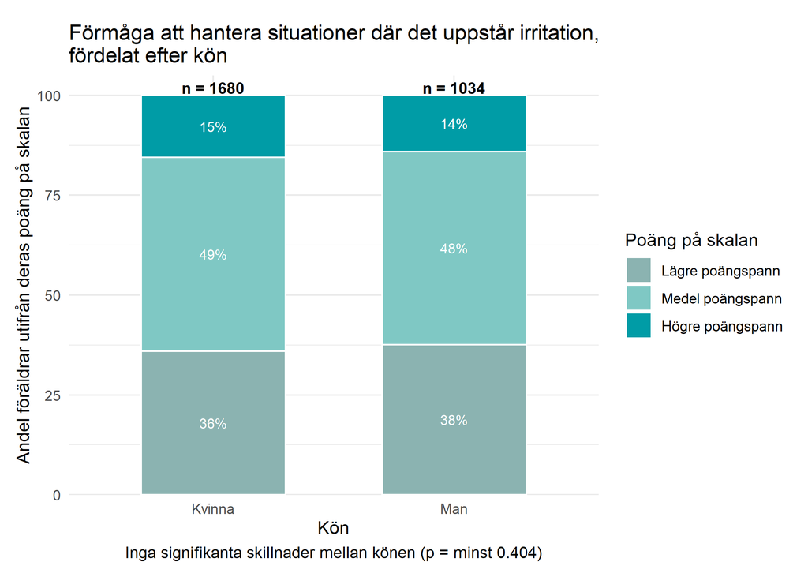

**Förmåga att hantera situationer där det uppstår irritation, fördelat efter stadsområde**

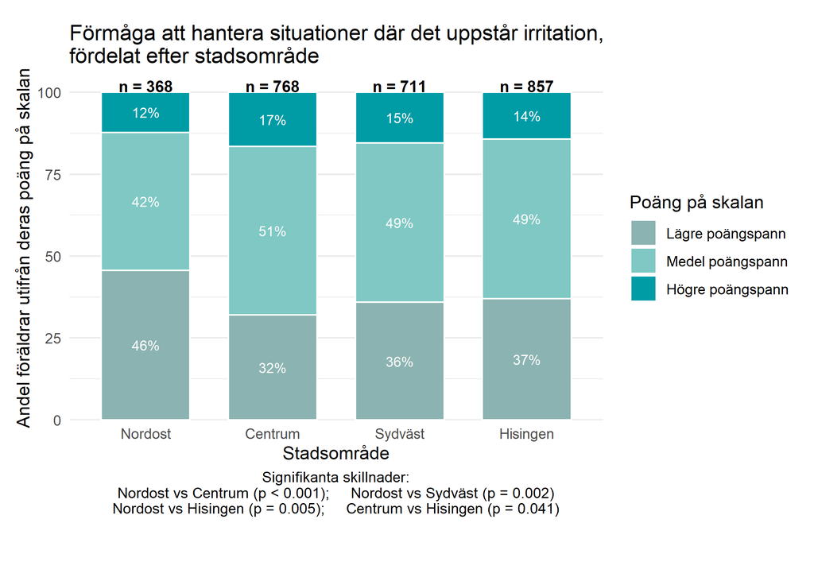

**Förmåga att hantera situationer där det uppstår irritation, fördelat efter antal barn**

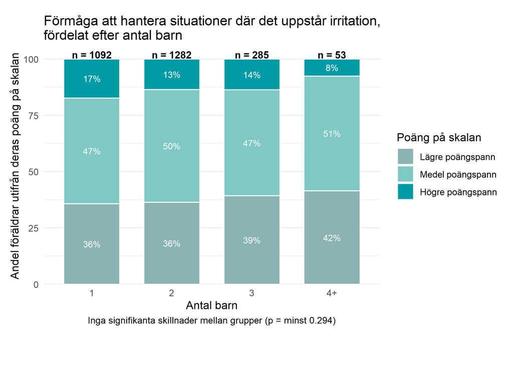

**Förmåga att hantera situationer där det uppstår irritation, fördelat efter utbildningsbakgrund**

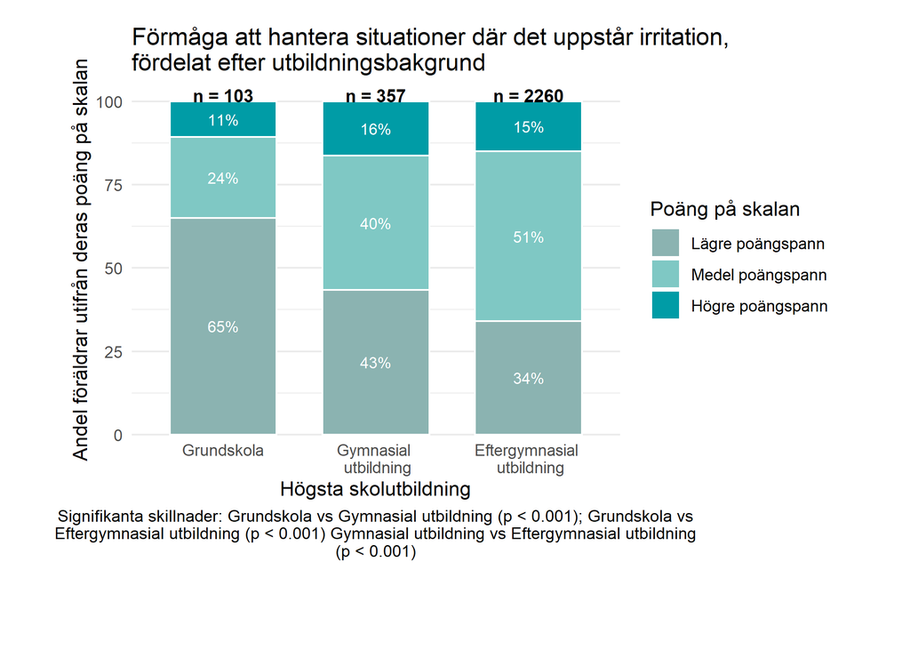

### 5.3.2 Förmåga att skapa positiv samvaro

När det gäller föräldrarnas förmåga att skapa positiv samvaro med barnet visar resultatet att en högre andel män (51%) än kvinnor (41%) kategoriseras i det lägre poängspannet. För denna specifika förmåga går det inte att identifiera några betydande skillnader mellan olika stadsområden.

**Förmåga att skapa positiv samvaro, efter kön**

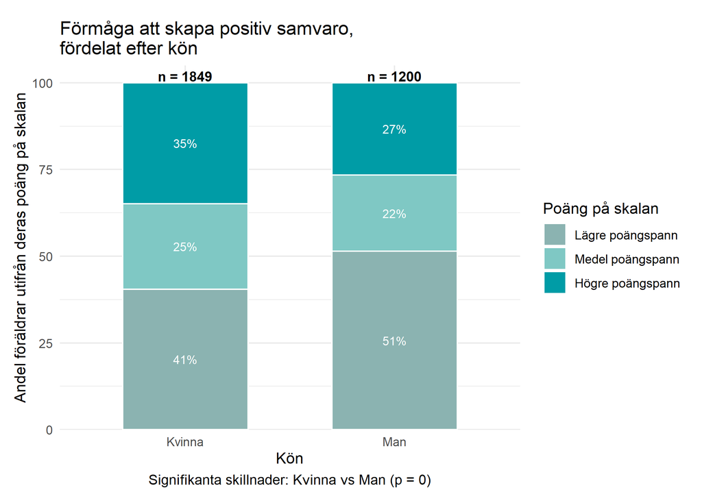

**Förmåga att skapa positiv samvaro, efter stadsområde**

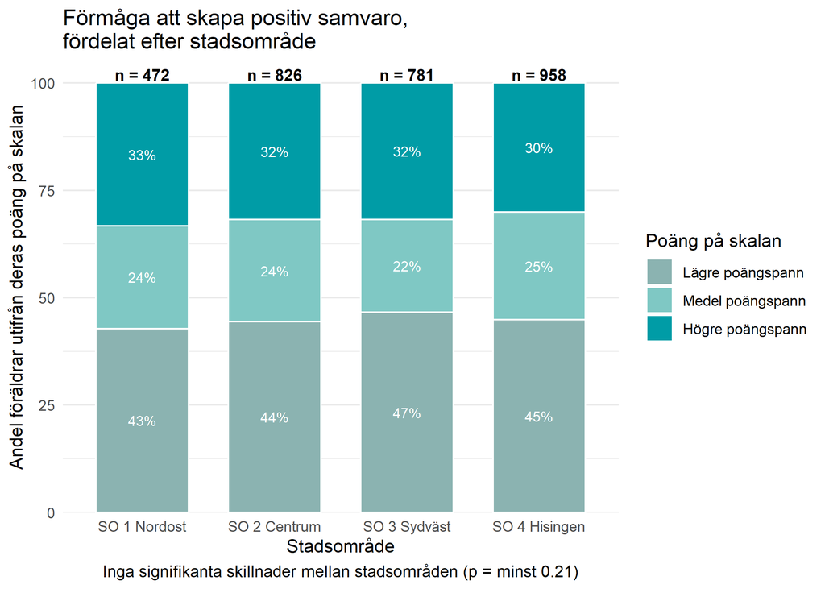

**Förmåga att skapa positiv samvaro, efter antal barn**

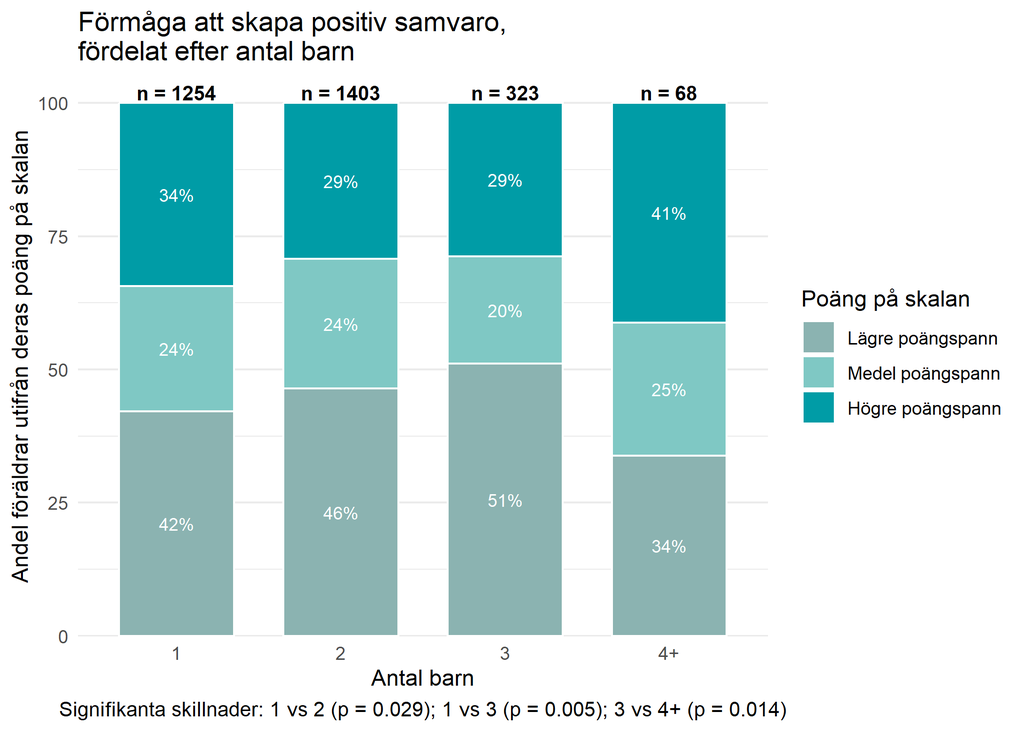

**Förmåga att skapa positiv samvaro, efter utbildningsbakgrund**

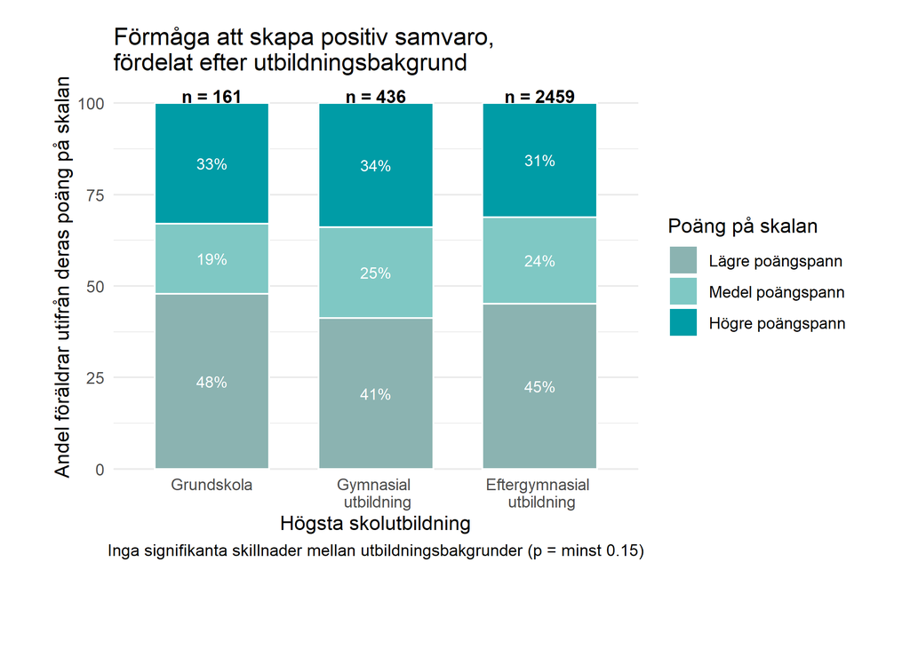

### 5.3.3 Förmåga att hantera oro eller rädsla hos barnet

Gällande föräldrarnas förmåga att hantera oro eller rädsla hos barnet visar resultatet att en högre andel män (62%) än kvinnor (46%) kategoriseras i det lägre poängspannet. Vid analys av stadsområden kunde inga signifikanta skillnader identifieras för denna förmåga. När det gäller familjestorlek framgår att en betydligt högre andel föräldrar med ett till tre barn (ca 52%) kategoriseras i det lägre poängspannet för hantering av oro och rädsla jämfört med föräldrar som har fyra barn eller fler (31%). Slutligen kunde inga skillnader i förmågan att hantera barnets oro eller rädsla identifieras utifrån föräldrarnas utbildningsbakgrund i detta material.

**Förmåga att hantera oro eller rädsla hos barnet, fördelat efter kön**

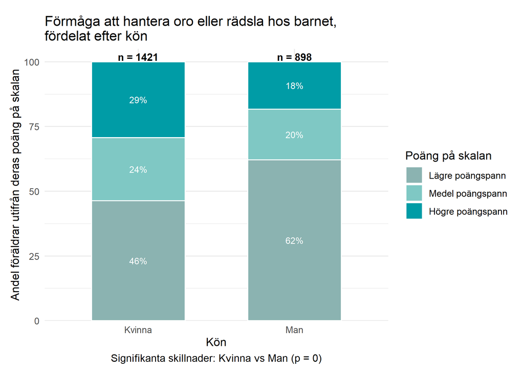

**Förmåga att hantera oro eller rädsla hos barnet, fördelat efter stadsområde**

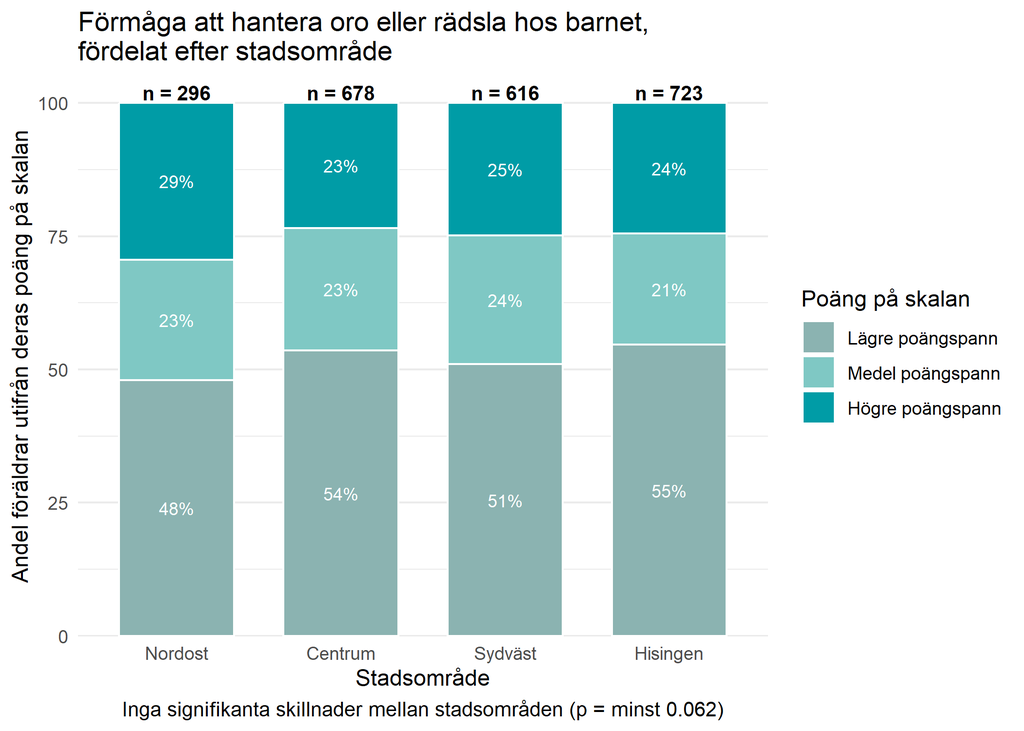

**Förmåga att hantera oro eller rädsla hos barnet, fördelat efter antal barn**

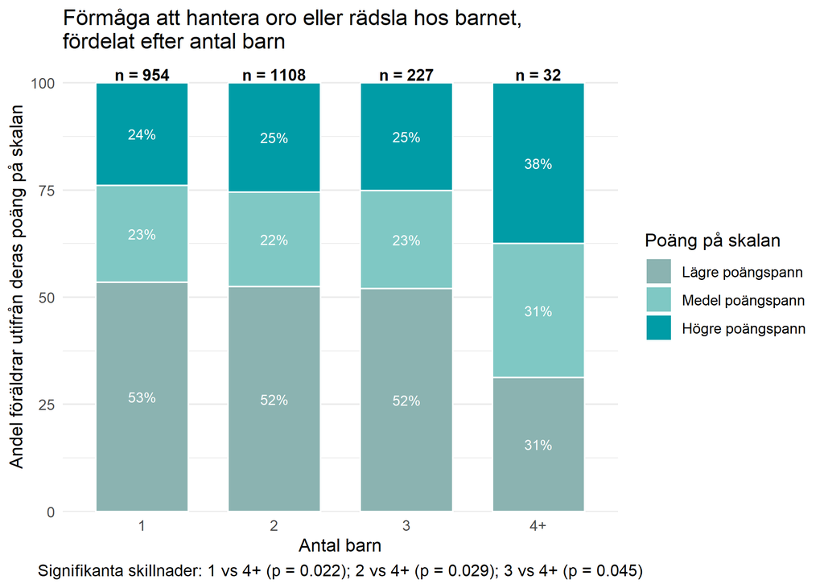

**Förmåga att hantera oro eller rädsla hos barnet, fördelat efter utbildningsbakgrund**

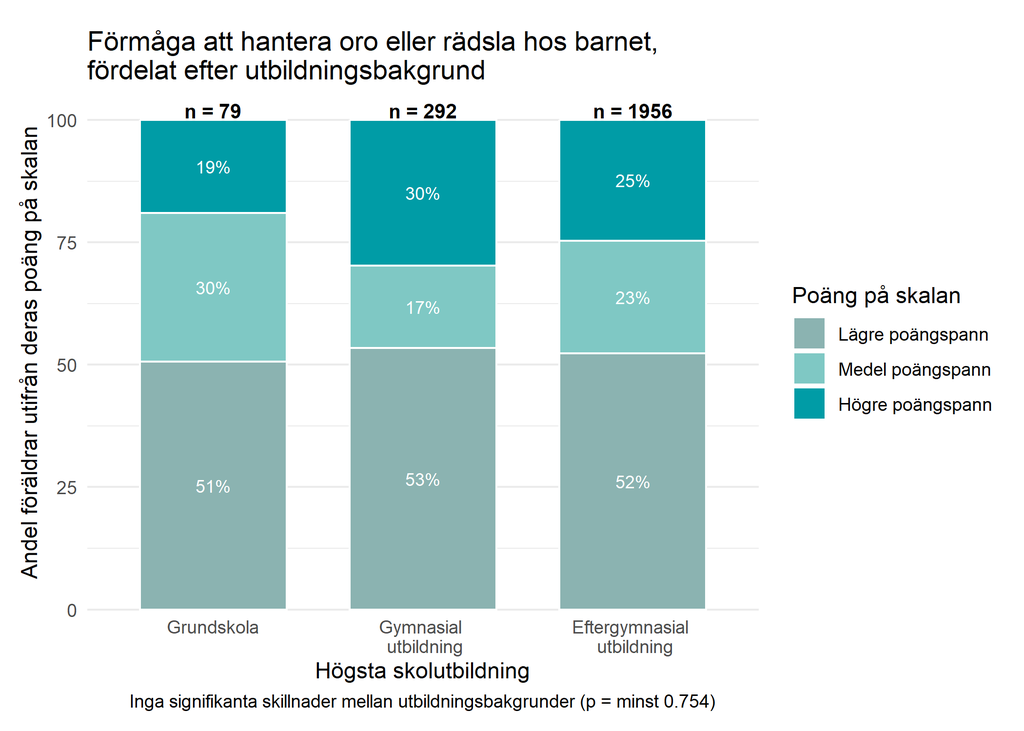

### 5.3.4 Förmåga att hantera situationer där det uppstår bråk

**Förmåga att hantera situationer där det uppstår bråk, fördelat efter kön**

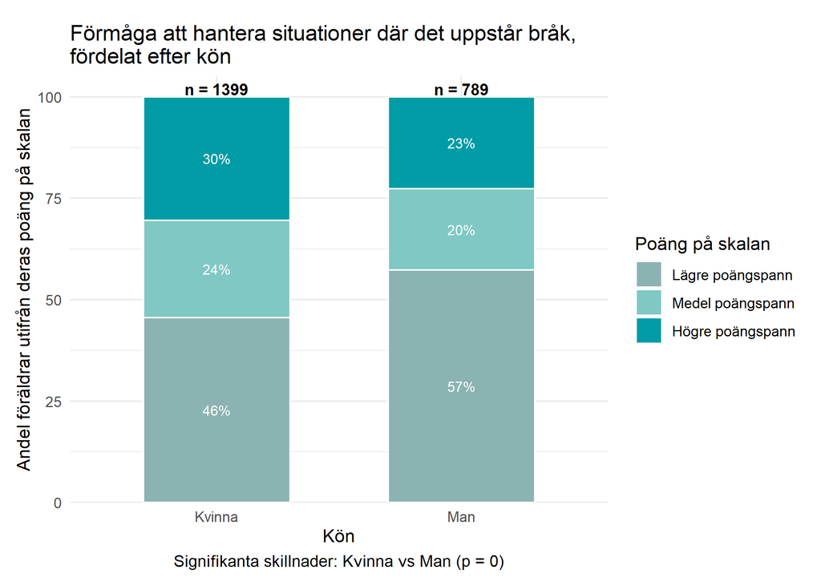

**Förmåga att hantera situationer där det uppstår bråk, fördelat efter stadsområde**

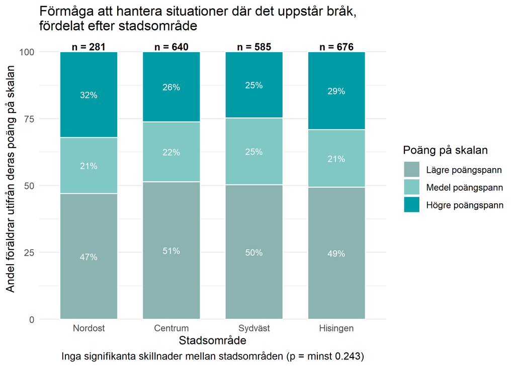

**Förmåga att hantera situationer där det uppstår bråk, fördelat efter antal barn**

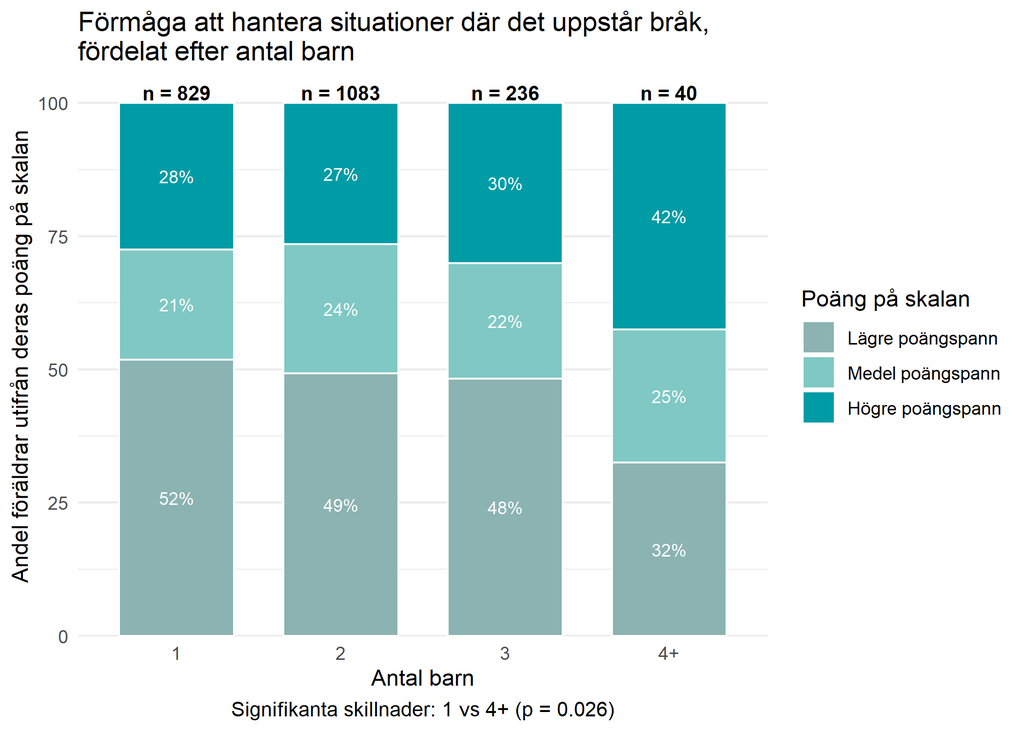

**Förmåga att hantera situationer där det uppstår bråk, fördelat efter utbildningsbakgrund**

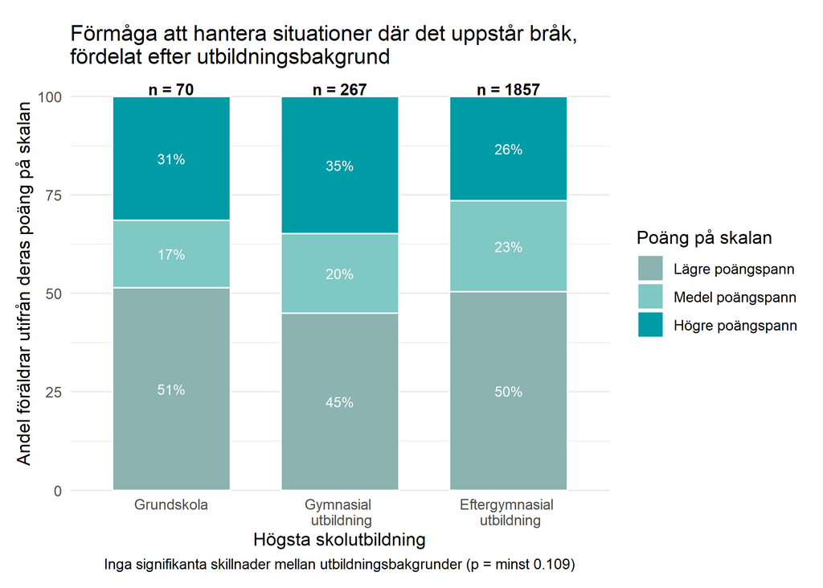

# 6 Sammanfattande slutsatser

I den här enkätundersökningen har vi undersökt föräldraförmåga utifrån fyra delindex kopplade till *förmåga att hantera situationer där det uppstår irritation, förmåga att skapa positiv samvaro, förmåga att hantera oro eller rädsla hos barnet samt förmåga att hantera situationer där det uppstår bråk* med syfte att undersöka om det finns skillnader i föräldraförmåga mellan olika grupper av föräldrar.

**Könsskillnader** Analysen visar att män i högre utsträckning än kvinnor kategoriseras i det lägre poängspannet inom tre av fyra undersökta områden. Störst skillnad noteras gällande förmågan att hantera oro eller rädsla hos barnet, där 62% av männen hamnar i det lägre spannet jämfört med 46% av kvinnorna. Liknande mönster ses vid hantering av situationer där det uppstår bråk (57% män mot 46% kvinnor) samt vid förmågan att skapa positiv samvaro (51% män mot 41% kvinnor). Gällande förmågan att hantera situationer där det uppstår irritation identifieras däremot inga mätbara skillnader; här uppvisar kvinnor och män en likvärdig förmåga.

**Skillnader mellan stadsområden** Geografiska skillnader i föräldraförmåga är endast framträdande gällande hantering av irritation. Här framgår en tydlig spridning där andelen i det lägre poängspannet är högst i Nordost (46%), följt av Sydväst och Hisingen (36–37%) och lägst i Centrum (32%). För de övriga tre områdena - positiv samvaro, hantering av oro och rädsla samt hantering av bråk - kunde inga signifikanta skillnader mellan stadsområdena identifieras i materialet.

**Skillnader i utbildningsbakgrund** Utbildningsnivå har en tydlig korrelation med föräldrarnas förmåga att hantera irritation. Föräldrar med grundskoleutbildning återfinns i betydligt högre grad i det lägre poängspannet (65%) jämfört med föräldrar med gymnasial utbildning (43%) och eftergymnasial utbildning (34%). I detta material kan inga motsvarande skillnader utifrån utbildningsbakgrund identifieras när det gäller de övriga tre förmågorna: att skapa positiv samvaro, hantera oro och rädsla eller hantera bråksituationer.

Den här tundersökningen utgör en pusselbit bland flera i att undersöka föräldraförmåga, men är långt ifrån att ge hela bilden. Det är viktigt att belysa att resultaten ska tolkas med försiktighet och att det inte går att dra några generella slutsatser om gruppen föräldrar i Göteborg baserat på enbart enkäten. Detta beror dels på att svarsfrekvensen är begränsad, dels på det faktum att enkäten endast fanns tillgänglig på svenska vilket kan påverka både urval av respondenter samt förståelsen för frågorna. Vidare finns det även en risk för informationsbias på grund av frågornas utformning och karaktär, det vill säga vilka som väljer att svara på enkäten samt hur de tolkar frågorna. Trots dessa begränsningar indikerar resultaten systematiska skillnader mellan olika föräldragrupper i förmågan att hantera specifika situationer med sitt/sina barn. Även om den interna variationen inom grupperna är betydande, synliggörs dimensioner där vissa föräldrar möter större utmaningar. Tillsammans ger resultaten en första indikation på områden där stödinsatser kan behövas och synliggör både styrkor och potentiella utvecklingsbehov. Detta är inte bara viktigt för att stärka föräldraskapet i allmänhet utan fokus på tidiga insatser kan också bidra till att öka skyddsfaktorer som påverkar barns välbefinnande och framtida livsvillkor, vilket även har bäring ur ett brottsförebyggande perspektiv. Resultaten utgör därmed ett underlag för att bättre förstå hur behoven varierar och vilka grupper som bör prioriteras i det fortsatta arbetet med föräldraskapsstöd.

# 7 Referenser

- Belsky, J. (1984). The determinants of parenting: A process model. *Child Development, 55*(1), 83–96. https://doi.org/10.2307/1129836
- Bronfenbrenner, U. (1979). *The ecology of human development: Experiments by nature and design.* Harvard University Press.
- Ndengeyingoma, A., Jacob, M. H., Beaulieu-Kratchanov, V., Berg, R., Garon-Carrier, G., Tremblay, R. E., & Parent, S. (2024). *Parenting competencies supporting the development of social and emotional skills of children—A scoping review*. Trends in Psychology, 32, 425–448. https://doi.org/10.1007/s43076-023-00182-1
- Odhnoff, C., Johansson, R., Preuter, M., & Larsson, C. (2024). *Kostnad och nytta av föräldraskapsstödet ABC-Slutrapportering av uppdrag i Göteborgs Stads budget 2022*. Socialförvaltningen Centrum, Göteborgs Stad. https://www.diva-portal.org/smash/get/diva2:1832734/FULLTEXT01.pdf
- Odhnoff, C. (2025). *Planering av föräldrastödsinsatser i framtidens socialtjänst*. Socialförvaltningen Centrum, Göteborgs Stad. https://goteborg.se/wps/wcm/connect/a48e90fd-7882-493a-9b94-bcdb1bbab5fa/SKU+2025+-+Planering+av+f%C3%B6r%C3%A4ldrast%C3%B6dsinsatser+i+framtidens+socialtj%C3%A4nst_tga.pdf?MOD=AJPERES
- RISE. (2021). *Risk- och skyddsfaktorer: Vad vet vi och vad kan göras med kunskapen?* RISE Rapport.
- RISE (2022). *Struktur och indikatorer för uppföljning av föräldraskapsstöd* (RISE rapport 2022:70). Research Institutes of Sweden (RISE).
- Socialstyrelsen. (2018). *Nationell strategi för ett stärkt föräldraskapsstöd: En vinst för alla*. https://www.socialstyrelsen.se/globalassets/sharepoint-dokument/artikelkatalog/ovrigt/2018-6-24.pdf (Hämtad 2026-02-24).
- Socialstyrelsen. (2024). *Barns behov i centrum (BBIC): Grundbok*. https://www.socialstyrelsen.se/contentassets/06b772880f314d5ab08a6a995448b371/2023-9-8734.pdf (Hämtad 2026-02-24).

# 8 Bilaga 1. Enkätfrågor

**Disclaimer**

Detta är den enkätversion som testades i samband med utvärderingen. Den inkluderar:

- bakgrundsfrågor
- samtliga frågor som låg till grund för analysen innan urval gjordes, inklusive frågor som har tagits bort utifrån analysens resultat
- frågor om föräldraskapsstöd i Göteborg.

Beskrivning av de fungerande delindex som tagits fram utifrån utvärderingen finns i avsnitt 4.1 till och med 4.5.

**Inledning**

I början av enkäten informeras deltagaren om följande:

*“Om du inte bor med ditt barn hela tiden eller träffar barnet mer sällan, svara utifrån den senaste tiden ni har varit tillsammans. Har du flera barn? Svara då utifrån den situation du upplever som mest utmanande just nu.”*

*“Enkäten tar 5 till 10 minuter att besvara och är anonym. Ditt deltagande i enkäten kommer inte medföra att någon identifierande information sparas om dig.”*

**Bakgrundsfrågor**:

- Vad är ditt kön?
- Delar du föräldraskapet med någon?
- Hur delar ni på föräldraansvaret?
- Vilken är din högsta skolutbildning?
- Är dina föräldrar födda i Sverige?

**Frågor om föräldraskapet**:

- Hur ofta har ditt barn gjort saker som irriterat eller stört dig under en typisk vecka tillsammans den senaste tiden?
- Hur hanterade du det? [Uttryckte dig lugnt, fast du kände dig irriterad eller arg.]
- Hur hanterade du det? [Avstod från att säga till om saker som störde dig, men som egentligen inte var så viktiga.]
- Under en typisk vecka tillsammans den senaste tiden, hur ofta har du…… [Gett ditt barn full uppmärksamhet en stund, utan att samtidigt vara upptagen med annat?]
- Under en typisk vecka tillsammans den senaste tiden, hur ofta har du…… [Visat nyfikenhet för något som barnet höll på med (t ex tittade på en stund när det ritade eller spelade datorspel).]
- Under en typisk vecka tillsammans den senaste tiden, hur ofta har du…… [Pratat om något som barnet ville prata om (t ex om något tv-program eller något som hänt under dagen eller i livet).]
- Under en typisk vecka tillsammans den senaste tiden, hur ofta har du…… [Visat omtanke eller uppskattning, även när ditt barn inte hade gjort något särskilt (t ex en kram utan direkt anledning).]
- Hur ofta har ditt barn gjort något du uppskattar under en typisk vecka tillsammans den senaste tiden?
- Hur ofta visade du ditt barn att du uppskattade det hen gjorde?
- Hur ofta har ditt barn varit oroligt eller ängsligt under en typisk vecka tillsammans den senaste tiden?
- Hur hanterade du det? [Lät ditt barn försöka lösa situationen på egen hand utan att du la dig i.]
- Hur hanterade du det? [Uppmuntrade ditt barn att prova, göra fel och försöka igen utan att du genast hjälpte till eller tog över.]
- Hur hanterade du det? [Pratade med barnet om hens känslor.]
- Hur hanterade du det? [Hjälpte lite på traven för att barnet skulle våga.]
- Hur ofta har ditt barn bråkat under en typisk vecka tillsammans den senaste tiden?
- Hur hanterade du det? [Försökte avleda konflikt, till exempel genom att börja skoja, busa eller prata om något annat.]
- Hur hanterade du det? [Visade förståelse för barnets känslor.]
- Hur hanterade du det? [Stod fast vid saker som ni hade bestämt, trots att barnet fortsatte att bråka.]

**Frågor om föräldraskapsstöd i Göteborgs Stad**:

- Hur väl känner du till följande typer av stöd som finns tillgängliga för föräldrar? [*Barnavårdscentral (BVC), Öppna förskolan, Familjecentral, Göteborgs Stads föräldratelefon, Kurser om föräldraskap (”föräldragrupper”) från Göteborgs Stad*]
- Har du hört talas om följande kurser om föräldraskap (”föräldragrupper”) som erbjuds av Göteborgs Stad? [*Alla barn i centrum (ABC) - 3-12 år, Alla barn i centrum (ABC) - Tonår, Trygghetscirkeln 0-6 år, Ledarskapsträning för tonårsföräldrar, Barn i föräldrars fokus, Förälder i nytt land*]
- Hur stort förtroende har du för råd om föräldraskap som du får från följande källor? [*Dina föräldrar, Personer du följer i sociala medier, Grupper för föräldrar på Facebook, 1177.se, Sjuksköterskor på barnavårdscentral (BVC), Pedagoger i förskolan, Föräldrastödjare på familjecentraler*]
- Finns det något du skulle vilja lära dig med när det gäller föräldraskap? [*Allmänt om barns utveckling och föräldrastrategier för olika åldrar, Hur man skapar bra regler kring skärmanvändning, Hur man sätter gränser för sina barn på ett bra sätt, Hur man hanterar yngre barn som är trotsiga, ljuger eller bråkar mycket, Hur man skapar och upprätthåller en förtroendefull relation till sin tonåring, Hur man skyddar barn från att dras in i ungdomskriminalitet, Annat*]
- Skulle du kunna tänka dig att nu eller någon gång i framtiden gå en ledarledd kurs i föräldraskap i grupp tillsammans med andra föräldrar?
- Varför skulle du inte vilja det? (Välj det alternativ som bäst stämmer överens med vad du tycker.) [*Jag vill inte gå tillsammans med andra föräldrar, Jag lär mig hellre på annat sätt, Jag tycker att det låter svårt, Jag tror inte att det kommer vara till någon nytta*]
- Har du några idéer eller feedback kring den här enkäten? Dela gärna dina synpunkter här!